# Project: Investigate a Dataset (TMDb Movies Dataset)

- 1. Introduction
- 2. Data Wrangling
- 3. Exploratory Data Analysis
- 4. Conclusions

## 1. Introduction

Films aren't cheap to produce and there are many ideas for new movies everyday. One can not possibly expect to put them all into action and as such, It's often necessary to have a keen insight in such a field to know which ideas are probably wothwhile and which aren't.

In this report, we are going to explore a dataset on movies gathered from the famous website "**TMDb**". This data includes interesting features like the movies rating, actors, revenue, etc.

We would like to study this dataset closely in an attempt to find out if it's possible to guess whether a movie is probable to be successful or not; or at the very least determine if there are some features that increases the chances of success for an upcoming film. In other words, we want to study the effects of the properties of a movie on its revenue.

### Specific questions we would like to know about:

1- What is the average length of a movie?  
2- Do overpriced, high-budget movies get more revenue?  
3- Does the runtime of a movie affect its ratings?  
4- Which companies seem to dominate the industry?  
5- Is the income of a movie heavily affected by its cast?  
6- Which genres are more popular overall?

```python
# Loading necessary packages
import numpy as np
import pandas as pd
import matplotlib.pyplot as plt

# The 'magic word' for the plotted visualizations.
%matplotlib inline
```

## 2. Data Wrangling

### General Properties

#### First, we load the dataset and try to get a general idea on the data

```python
#load the Data file
df = pd.read_csv('tmdb-movies.csv')

# Take a look at the first few rows
df.head()
```

|  | id | imdb_id | popularity | budget | revenue | original_title | cast | homepage | director | tagline | ... | overview | runtime | genres | production_companies | release_date | vote_count | vote_average | release_year | budget_adj | revenue_adj |
| --- | --- | --- | --- | --- | --- | --- | --- | --- | --- | --- | --- | --- | --- | --- | --- | --- | --- | --- | --- | --- | --- |
| 0 | 135397 | tt0369610 | 32.985763 | 150000000 | 1513528810 | Jurassic World | Chris Pratt\|Bryce Dallas Howard\|Irrfan Khan\|Vi... | http://www.jurassicworld.com/ | Colin Trevorrow | The park is open. | ... | Twenty-two years after the events of Jurassic ... | 124 | Action\|Adventure\|Science Fiction\|Thriller | Universal Studios\|Amblin Entertainment\|Legenda... | 6/9/15 | 5562 | 6.5 | 2015 | 1.379999e+08 | 1.392446e+09 |
| 1 | 76341 | tt1392190 | 28.419936 | 150000000 | 378436354 | Mad Max: Fury Road | Tom Hardy\|Charlize Theron\|Hugh Keays-Byrne\|Nic... | http://www.madmaxmovie.com/ | George Miller | What a Lovely Day. | ... | An apocalyptic story set in the furthest reach... | 120 | Action\|Adventure\|Science Fiction\|Thriller | Village Roadshow Pictures\|Kennedy Miller Produ... | 5/13/15 | 6185 | 7.1 | 2015 | 1.379999e+08 | 3.481613e+08 |
| 2 | 262500 | tt2908446 | 13.112507 | 110000000 | 295238201 | Insurgent | Shailene Woodley\|Theo James\|Kate Winslet\|Ansel... | http://www.thedivergentseries.movie/#insurgent | Robert Schwentke | One Choice Can Destroy You | ... | Beatrice Prior must confront her inner demons ... | 119 | Adventure\|Science Fiction\|Thriller | Summit Entertainment\|Mandeville Films\|Red Wago... | 3/18/15 | 2480 | 6.3 | 2015 | 1.012000e+08 | 2.716190e+08 |
| 3 | 140607 | tt2488496 | 11.173104 | 200000000 | 2068178225 | Star Wars: The Force Awakens | Harrison Ford\|Mark Hamill\|Carrie Fisher\|Adam D... | http://www.starwars.com/films/star-wars-episod... | J.J. Abrams | Every generation has a story. | ... | Thirty years after defeating the Galactic Empi... | 136 | Action\|Adventure\|Science Fiction\|Fantasy | Lucasfilm\|Truenorth Productions\|Bad Robot | 12/15/15 | 5292 | 7.5 | 2015 | 1.839999e+08 | 1.902723e+09 |
| 4 | 168259 | tt2820852 | 9.335014 | 190000000 | 1506249360 | Furious 7 | Vin Diesel\|Paul Walker\|Jason Statham\|Michelle ... | http://www.furious7.com/ | James Wan | Vengeance Hits Home | ... | Deckard Shaw seeks revenge against Dominic Tor... | 137 | Action\|Crime\|Thriller | Universal Pictures\|Original Film\|Media Rights ... | 4/1/15 | 2947 | 7.3 | 2015 | 1.747999e+08 | 1.385749e+09 |

5 rows × 21 columns

We can immediately see that the data contain some useful information like **`budget`, `revenue`, `vote_average`** and others that may be of interest for us.

On the other hand, we can see that the **`release_year`** doesn't particularly add any new information due to the presence of **`release_date`**, so it may be dropped.

However, since our questions aren't particularly concerned with such detailed release date but more interested in the year of release, we may drop the **`release_date`** instead for ease of analysis.

#### Next, we check the columns and other general information on the dataset

```python
# See column names and which contain sum Null values, data types, etc.
df.info()
```

```
<class 'pandas.core.frame.DataFrame'>
RangeIndex: 10866 entries, 0 to 10865
Data columns (total 21 columns):
 #   Column                Non-Null Count  Dtype
---  ------                --------------  -----
 0   id                    10866 non-null  int64
 1   imdb_id               10856 non-null  object
 2   popularity            10866 non-null  float64
 3   budget                10866 non-null  int64
 4   revenue               10866 non-null  int64
 5   original_title        10866 non-null  object
 6   cast                  10790 non-null  object
 7   homepage              2936 non-null   object
 8   director              10822 non-null  object
 9   tagline               8042 non-null   object
 10  keywords              9373 non-null   object
 11  overview              10862 non-null  object
 12  runtime               10866 non-null  int64
 13  genres                10843 non-null  object
 14  production_companies  9836 non-null   object
 15  release_date          10866 non-null  object
 16  vote_count            10866 non-null  int64
 17  vote_average          10866 non-null  float64
 18  release_year          10866 non-null  int64
 19  budget_adj            10866 non-null  float64
 20  revenue_adj           10866 non-null  float64
dtypes: float64(4), int64(6), object(11)
memory usage: 1.7+ MB
```

We can see that **`release_date`** is of datatype `object` (string) not `datetime64` because there is no time (only a date).

Features like **`id`, `imdb_id`, `tagline`, `homepage`, `overview`** may also be dropped as they probably won't contribute in our analysis.

Others like **`cast`, `director`, `keywords`, `genres`, `production_companies`** have missing data (null values) that need to be dealt with.

Also, **`budget`, `revenue`** can be dropped as **`budget_adj`, `revenue_adj`** would suffice as a more objective comparing criteria.

All columns are named in lowercase and only contain underscores, so we won't probably need to modify any names of columns.

**Note**: Most column names are self-explanatory, but here are some of them that might be a bit ambigious and needed further research on the original website (TMDb) and the dataset source (Kaggle):

| Column Name | Description |
| --- | --- |
| id | Movie ID on TMDb link |
| imdb_id | Movie ID on IMDb link |
| popularity | A score for the movie reflecting its popularity amongst fans |
| budget | Estimated amount of money in US Dollars spent on production of the movie at the time of its release |
| revenue | Revenue in US Dollars won by the movie at the time of its release |
| tagline | A catchphrase for the movie |
| keywords | Useful for searching for movies |
| runtime | Length of the movie in minutes |
| budget_adj | budget adjusted for todays US Dollar worth |
| revenue_adj | revenue adjusted for todays US Dollar worth |

#### Now, we Check for duplicate rows

```python
sum(df.duplicated())
```

```
1
```

### Data Cleaning

#### 1. Dropping Duplicated Rows

```python
df.drop_duplicates(inplace=True)
```

#### 2. Dropping Columns of Unwanted Features

```python
df.drop(['id', 'imdb_id', 'tagline', 'homepage', 'overview', 'budget', 'revenue', 'release_date'], axis=1, inplace=True)
```

#### 3. Dealing with Null-Values

Since the Null-Values in this dataset are of type string, it would be difficult to replace them with a mean or some other kind of actual data. Thus, we will opt out to dropping these Missing data instead.

```python
# Dropping colmuns with too much missing data (Null-values)
df.drop(['cast', 'keywords', 'production_companies'], axis=1, inplace=True)
```

```python
# Dropping remaining rows with Null-values (in columns 'genres', 'director')
df = df.dropna()
```

#### 4. Changing index to movie names

```python
# Renaming the column to 'title'
df = df.rename(columns={'original_title': 'title'})

# Replacing index with 'title' column
df.index = df['title']
df = df.drop(columns='title')
```

#### Checking our cleaned data

```python
df.head()
```

| title | popularity | director | runtime | genres | vote_count | vote_average | release_year | budget_adj | revenue_adj |
| --- | --- | --- | --- | --- | --- | --- | --- | --- | --- |
| Jurassic World | 32.985763 | Colin Trevorrow | 124 | Action\|Adventure\|Science Fiction\|Thriller | 5562 | 6.5 | 2015 | 1.379999e+08 | 1.392446e+09 |
| Mad Max: Fury Road | 28.419936 | George Miller | 120 | Action\|Adventure\|Science Fiction\|Thriller | 6185 | 7.1 | 2015 | 1.379999e+08 | 3.481613e+08 |
| Insurgent | 13.112507 | Robert Schwentke | 119 | Adventure\|Science Fiction\|Thriller | 2480 | 6.3 | 2015 | 1.012000e+08 | 2.716190e+08 |
| Star Wars: The Force Awakens | 11.173104 | J.J. Abrams | 136 | Action\|Adventure\|Science Fiction\|Fantasy | 5292 | 7.5 | 2015 | 1.839999e+08 | 1.902723e+09 |
| Furious 7 | 9.335014 | James Wan | 137 | Action\|Crime\|Thriller | 2947 | 7.3 | 2015 | 1.747999e+08 | 1.385749e+09 |

```python
df.info()
```

```
<class 'pandas.core.frame.DataFrame'>
Index: 10800 entries, Jurassic World to Manos: The Hands of Fate
Data columns (total 9 columns):
 #   Column        Non-Null Count  Dtype
---  ------        --------------  -----
 0   popularity    10800 non-null  float64
 1   director      10800 non-null  object
 2   runtime       10800 non-null  int64
 3   genres        10800 non-null  object
 4   vote_count    10800 non-null  int64
 5   vote_average  10800 non-null  float64
 6   release_year  10800 non-null  int64
 7   budget_adj    10800 non-null  float64
 8   revenue_adj   10800 non-null  float64
dtypes: float64(4), int64(3), object(2)
memory usage: 843.8+ KB
```

## 3. Exploratory Data Analysis

### First, we look at some summary statistics to get a general understanding of the cleaned dataset

```python
df.describe()
```

|  | popularity | runtime | vote_count | vote_average | release_year | budget_adj | revenue_adj |
| --- | --- | --- | --- | --- | --- | --- | --- |
| count | 10800.000000 | 10800.000000 | 10800.000000 | 10800.000000 | 10800.000000 | 1.080000e+04 | 1.080000e+04 |
| mean | 0.649455 | 102.189722 | 218.600741 | 5.970880 | 2001.289537 | 1.765437e+07 | 5.167714e+07 |
| std | 1.002441 | 30.783873 | 577.165055 | 0.933006 | 12.819545 | 3.438403e+07 | 1.450182e+08 |
| min | 0.000188 | 0.000000 | 10.000000 | 1.500000 | 1960.000000 | 0.000000e+00 | 0.000000e+00 |
| 25% | 0.209157 | 90.000000 | 17.000000 | 5.400000 | 1995.000000 | 0.000000e+00 | 0.000000e+00 |
| 50% | 0.385471 | 99.000000 | 39.000000 | 6.000000 | 2006.000000 | 0.000000e+00 | 0.000000e+00 |
| 75% | 0.717508 | 111.250000 | 147.000000 | 6.600000 | 2011.000000 | 2.103337e+07 | 3.408743e+07 |
| max | 32.985763 | 900.000000 | 9767.000000 | 9.200000 | 2015.000000 | 4.250000e+08 | 2.827124e+09 |

Also, the average movie timespan is about 102 minutes (1 hour and 42 minutes) and the average adjusted revenue is close to about \$51677140.

The scores in the **`popularity`** column seem to range from **0.000188** to **32.985763**. Also, upon further research, one couldn't actually find out how this score was calculated. So, we may opt out to not using it altogether.

### Second, we look at mapping for the various features with each other to strengthen our intuition

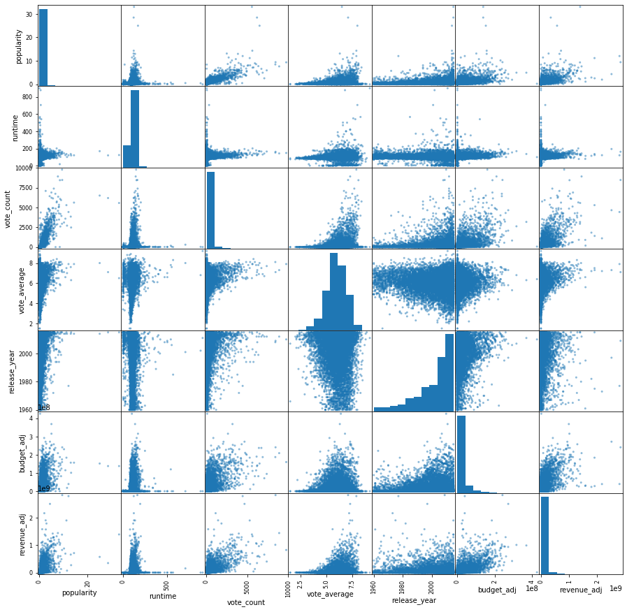

```python
pd.plotting.scatter_matrix(df,figsize=(15, 15));
```

### Research Question 1 (What is the average length of a movie?)

This was already answered above as 102 minutes (1 hour and 42 minutes).

### Research Question 2 (Do overpriced, high-budget movies get more revenue?)

We plot the graph between the budget and revenue as follows:

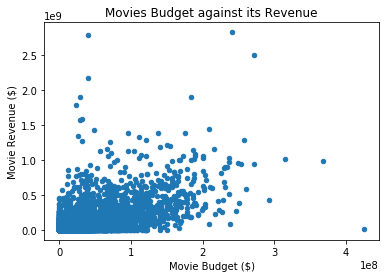

```python
# defining function for plotting features x, y in scatter form with appropriate title names
def scatter_plt(x_ax, y_ax, x_label, y_label, graph_title):
    p1 = df.plot(x=x_ax, y=y_ax, kind='scatter', title=graph_title)
    p1.set_xlabel(x_label)
    p1.set_ylabel(y_label);

# plotting the graph between the Movies budget and Revenue
scatter_plt('budget_adj', 'revenue_adj', 'Movie Budget ($)', 'Movie Revenue ($)', 'Movies Budget against its Revenue')
```

We can see a positive correlation between both which may be explained by saying that the more budget is spent on a movie, the more it can become more aesthetically pleasing, and as such more people enjoy it. However, of course that is just wild guessing and can not be used to imply causation from correlation!

## Research Question 3 (Does the runtime of a movie affect its ratings?)

We plot the graph between the runtime and average score based on votes

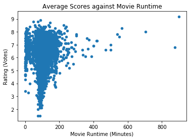

```python
scatter_plt('runtime', 'vote_average', 'Movie Runtime (Minutes)', 'Rating (Votes)', 'Average Scores against Movie Runtime')
```

We find that there is a certain area where the runtime is less than average (near 75 minutes approximately)

We also plot the graph between the runtime and revenue to get a clearer picture

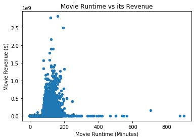

```python
scatter_plt('runtime', 'revenue_adj', 'Movie Runtime (Minutes)', 'Movie Revenue ($)', 'Movie Runtime vs its Revenue');
```

We now see the exact opposite! The same area has more revenues!

The graph looks like a normal distribution curve that is skewed to the right.

This is actually due to the average runtime being 102 as mentioned above. That is, most movies are in this region and as such many data is clustered there; No clear conclusion can be based on this due to lack of density of data in other regions.

### Research Question 6 (Which genres are popular over all years?)

We plot the popularity of each genre during the period from 1960 till 2015

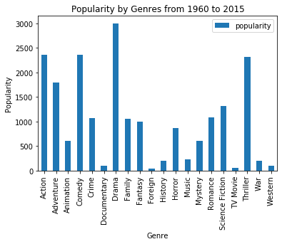

```python
# defining a function for plotting a certain feature against all genres over the time period of our data with approptiate formatting
def genres_all_years(feature, y_label, graph_title):
    s = df.copy()
    plt_genre = s['genres'].str.split('|', expand=True).stack().to_frame(name='genre')
    plt_genre.index = plt_genre.index.droplevel(1)
    plt_genre = plt_genre.join(s[feature]).groupby('genre').sum()
    plt = plt_genre.plot(kind='bar', title=graph_title)
    plt.set_xlabel('Genre')
    plt.set_ylabel(y_label)

# plotting the popularity of each genre during the period from 1960 till 2015
genres_all_years('popularity', 'Popularity', 'Popularity by Genres from 1960 to 2015')
```

We see that the top 5 most popular genres are:

1- Drama  
2- Action, Thriller, Comedy  
3- Adventure

However, as mentioned above, the actual equation for popularity or any explanation regarding its values are nowhere to be found. As such, we may instead find it more appealing to try to use the revenue feature instead as a reference to the popularity

We plot the revenue of each genre during the period from 1960 till 2015

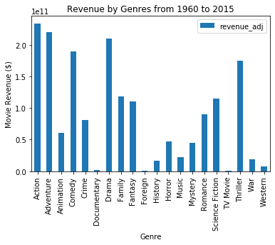

```python
# plotting the revenue of each genre during the period from 1960 till 2015
genres_all_years('revenue_adj', 'Movie Revenue ($)', 'Revenue by Genres from 1960 to 2015')
```

Which are exactly the same 5 genres as above (most popular genres).

## 4. Conclusions

In this report, we had a dataset from a movie database and wanted to study the effect of various features on the revenue. Unforetunately, we had to drop a multitude of features from our original dataset which hindered us from answering some of our proposed questions.

After that, using plotting and some summary statistcs we could answer most of the remaining questions:

- We determined the average timespan of a movie.
- We saw the relation between movie budget and revenue.
- We determined that runtime doesn't seem to affect revenue.
- We determined the top 5 genres of movies from 1960~2015.